# GGM Simulation. Transfer learning

```r
library(modelSelection)
library(mvtnorm)
library(tidyverse)
library(lamW)      # Lambert's W_q function
set.seed(20260710) # for reproducibility
save2pdf <- TRUE
nsims <- 20 # number of simulations
nseq <- c(10, 20, 100) # sample sizes
kseq <- c(20, 50) # problem dimensions
names(kseq) <- paste('k=', kseq, sep='')
```

# Set default prior parameters

1. A default $\lambda=1$, and $\sigma^2=1$.
2. A default $\lambda=1$, with $\sigma^2$ specified such that $P(\Theta \succ 0) = 0.95$. This guarantees that the total variation distance between the priors before and after positive-definiteness truncation is small, and hence that the prior is interpretable.
3. Set $\lambda$ such that $P(\Theta_{ii} \succ 0 \mid Z) \geq 1 - \alpha$ for every edge configuration $Z$ and taking $\alpha=0.1$, and $\sigma^2=1$.

```r
edge_prob_succ= 5 # prior number of successes
edge_prob_fail= 95 # prior number of failures
mu = 9.5       # mean of off-diagonal
lambda= 2/mu
```

We next obtain the value of $\lambda$ for Setting 3.

```r
sd.slab <- 1
alpha <- 0.1
x <- - alpha^2 /(32 * exp(2) * kseq^2)
l <- lambertWm1(x) # q = -1 branch of Lambert's W_q function
mu <- (2 * sd.slab * kseq^(3/2) / alpha) * sqrt(-l)
lambda2 <- 2/mu
names(lambda2) <- names(kseq)
lambda2
```

```
##         k=20         k=50
## 2.564461e-04 6.181495e-05
```

We store the prior parameter values obtained for each setting and $k = \mbox{dim}(\Theta)$.

```r
priorpars <- expand.grid(setting=c('Setting 1', 'Setting 3'), k=kseq)
priorpars$edge_prob_succ <- edge_prob_succ
priorpars$edge_prob_fail <- edge_prob_fail
priorpars$lambda <- priorpars$var.slab <- NA
for (i in 1:nrow(priorpars)) {
  if (priorpars$setting[i] == 'Setting 1') {
    priorpars$lambda[i] <- 1
    priorpars$var.slab[i] <- 1
  } else if (priorpars$setting[i] == 'Setting 3') {
    priorpars$lambda[i] <- lambda2[paste('k=', priorpars$k[i], sep='')]
    priorpars$var.slab[i] <- 1
  }
}
priorpars
```

```
##     setting  k edge_prob_succ edge_prob_fail var.slab       lambda
## 1 Setting 1 20              5             95        1 1.000000e+00
## 2 Setting 3 20              5             95        1 2.564461e-04
## 3 Setting 1 50              5             95        1 1.000000e+00
## 4 Setting 3 50              5             95        1 6.181495e-05
```

# Prior distribution on model size

We first plot the prior on the model size before truncation.

```r
dbetabin <- function(x, n, alpha, beta) {
  ans <- lchoose(n, x) + lgamma(x + alpha) + lgamma(n - x + beta) - lgamma(n + alpha + beta) - lgamma(alpha) - lgamma(beta) + lgamma(alpha + beta)
  exp(ans)
}
```

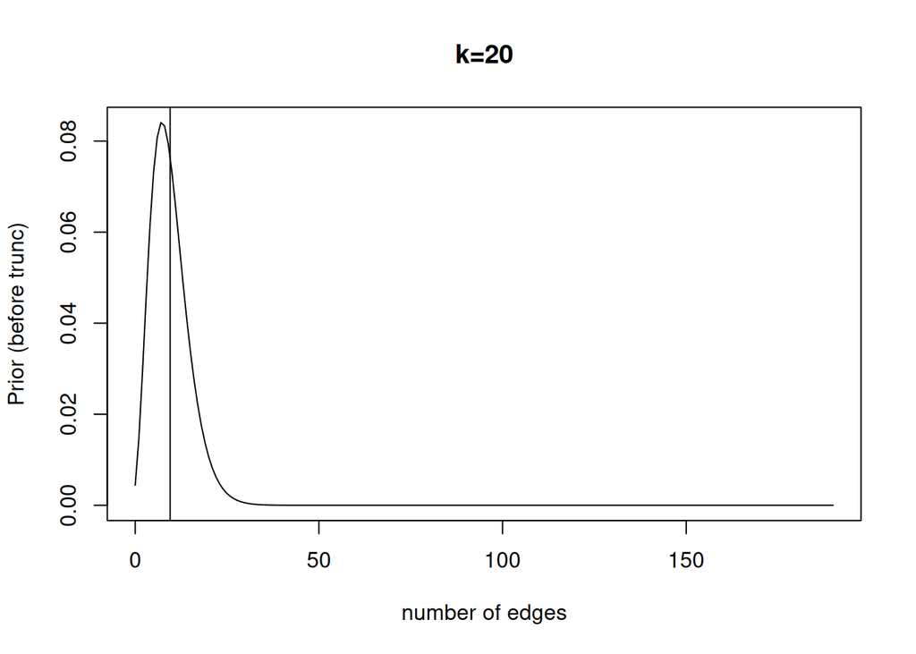

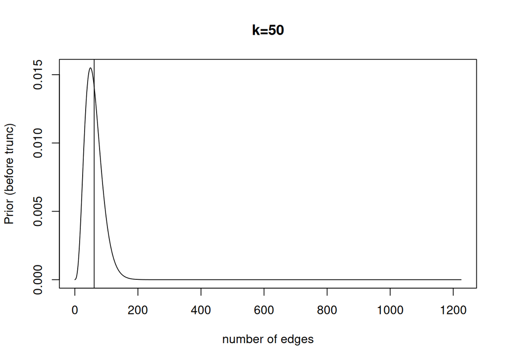

```r
for (i in 1:length(kseq)) {
  maxedges <- (kseq[i] * (kseq[i] - 1) / 2)
  plot(0:maxedges, dbetabin(0:maxedges, n=maxedges, edge_prob_succ, edge_prob_fail), type='l', ylab='Prior (before trunc)', xlab="number of edges", main=paste0('k=',kseq[i]))
  abline(v= maxedges * edge_prob_succ / (edge_prob_succ + edge_prob_fail))
}
```

Now, the prior on the model size after the +def truncation.

```r
niter <- 50000
priorModel <- modelbbprior(edge_prob_succ, edge_prob_fail)
priorCoef <- normalidprior(1)
priorDiag <- exponentialprior(1)
simprior <- vector("list", length(kseq))
for (i in 1:length(kseq)) {
  y <- matrix(nrow=0, ncol=kseq[i])
  simprior[[i]] <- modelSelectionGGM(y, priorCoef=priorCoef, priorDiag=priorDiag, priorModel=priorModel, niter=niter, verbose=TRUE)
}
```

```
##  Obtaining initial parameter estimate...
```

```
##  Done
```

```
##  Obtaining posterior samples
## 0%10%20%30%40%50%60%70%80%90% Done
```

```
##  Obtaining initial parameter estimate...
##  Done
```

```
##  Obtaining posterior samples
## 0%10%20%30%40%50%60%70%80%90% Done
```

```r
total_edges <- vector("list", length(kseq))
for (i in 1:length(kseq)) {
  diagentry <- simprior[[i]]$indexes[1,] == simprior[[i]]$indexes[2,]
  total_edges[[i]] <- rowSums(as.matrix(simprior[[i]]$postSample[,!diagentry] != 0))
}

nedges <- data.frame(number_edges = unlist(total_edges), k= rep(kseq, sapply(total_edges, length)))
```

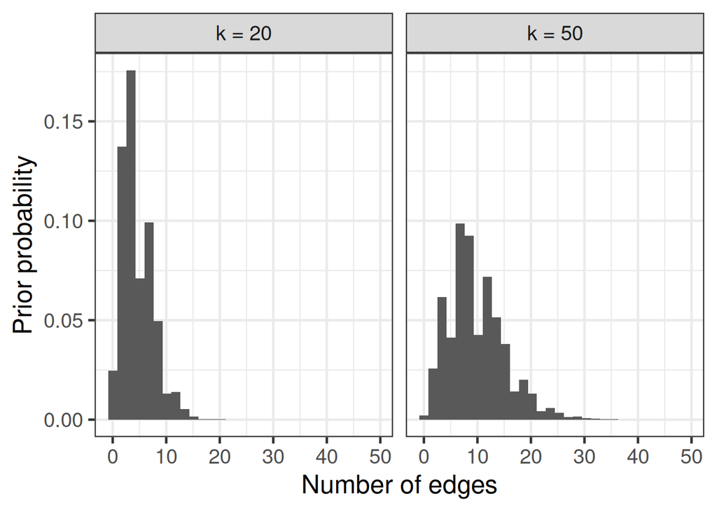

```r
ggplot(nedges, aes(x=number_edges)) +
  geom_histogram(aes(y = after_stat(density)), position="identity") +
  facet_wrap(~ k, labeller = labeller(k = function(x) paste0("k = ", x))) +
  labs(x = "Number of edges", y = "Prior probability") +
  theme_bw(base_size = 18) +
  scale_color_grey()
```

# Function to run simulations

We create a function that simulates data from a multivariate Gaussian, fits a Bayesian Gaussian graphical model model under a discrete spike-and-slab prior, and record the mean squared estimation error, the average estimate of each $\theta_{ij}$ entry, and the average posterior probability $P(\theta_{ij} \neq 0 \mid y)$.

```r
run_simulations <- function(n, nsims, Theta, Sigma=solve(Theta), priorCoef, priorDiag, priorModel, scale=TRUE) {
  posterior_coef = posterior_nbedges = vector("list", nsims)
  for (i in 1:nsims) {
    set.seed(i)  #for reproducibility

    ansi = ansi_nbedges = vector("list", length(n))
    for (j in 1:length(n)) {

      # Simulate data
      samplesize <- n[j]
      y = rmvnorm(samplesize, sigma= Sigma)
      sy = apply(y, 2, 'sd')

      # Fit models
      fit = modelSelectionGGM(y=y, priorCoef=priorCoef, priorDiag=priorDiag, priorModel=priorModel, center=scale, scale=scale, verbose=FALSE)

      # Posterior distribution on the number of edges
      diagentry <- fit$indexes[1,] == fit$indexes[2,]
      ansi_nbedges[[j]] <- data.frame(number_edges = rowSums(as.matrix(fit$postSample[,!diagentry] != 0)), n = samplesize)

      # Extract BMA parameter estimates and posterior edge inclusion probabilities
      b= data.frame(coef(fit)) |>
        select(row, column, estimate, margpp)

      # Convert to original scale
      scaling = 1 / (sy[b$row] * sy[b$column])
      b = transform(b, estimate= estimate * scaling)

      # Add data-generating truth
      if (i==1) {
        truth = double(nrow(b))
        for (l in 1:nrow(b)) truth[l] = Theta[b$row[l], b$column[l]]
      }
      b$truth = truth

      # Record MSE, average posterior inclusion probability and average point estimate
      ansi[[j]] = group_by(b, truth) |>
                 summarize(mse = mean((truth - estimate)^2), pp = mean(margpp), mean_estimate = mean(estimate), count = n()) |>
                 cbind(simid = i, n = samplesize)

      cat('.')

    }

    posterior_coef[[i]] <- do.call(rbind, ansi)
    posterior_nbedges[[i]] <- do.call(rbind, ansi_nbedges)
  }
  ans = list(posterior_coef=posterior_coef, posterior_nbedges=posterior_nbedges)
  return(ans)
}
```

# Erdos-Renyi graph

## Run simulations

```r
true_edge_prob <- edge_prob_succ / (edge_prob_succ + edge_prob_fail)
sims1 <- sims3 <- Theta_truth <- vector("list", length(kseq))
names(sims1) <- names(sims3) <- names(kseq)
diagvals <- vector("list", length(kseq))
for (i in 1:length(kseq)) {
  ksel <- kseq[i]  # number of variables
  cat("Simulations for k =", ksel)

  # Data-generating precision matrix
  y <- matrix(nrow=0, ncol=ksel)
  sample <- modelSelectionGGM(y, priorCoef=normalidprior(1), priorModel=modelbinomprior(true_edge_prob), priorDiag=exponentialprior(1), niter=5000, verbose=FALSE)  # simulate from prior

  diagentry <- sample$indexes[1,] == sample$indexes[2,]
  sample_edges <- rowSums(as.matrix(sample$postSample[,!diagentry] != 0))
  diff_edges <- abs(sample_edges - true_edge_prob * ksel * (ksel - 1) / 2)
  sel <- rev(which(diff_edges == min(diff_edges)))[1]  # take draw closest to true edge prob
  Theta <- diag(ksel)
  thetavals <- sample$postSample[sel,]
  for (j in 1:ncol(sample$indexes)) {
    Theta[sample$indexes['row',j], sample$indexes['column',j]] <- thetavals[j]
    Theta[sample$indexes['column',j], sample$indexes['row',j]] <- thetavals[j]
  }
  Sigma <- solve(Theta)
  diagvals[[i]] <- unique(diag(Theta))
  Theta_truth[[i]] <- Theta

  # Set prior distribution under each setting
  pars_sel <- filter(priorpars, setting == "Setting 1", k == ksel)
  priorModel <- modelbbprior(pars_sel$edge_prob_succ, pars_sel$edge_prob_fail)
  priorDiag <- exponentialprior(lambda = pars_sel$lambda)
  priorCoef <- normalidprior(pars_sel$var.slab)
  sims1[[i]] <- run_simulations(n=nseq, nsims=nsims, Theta=Theta, Sigma=solve(Theta), priorCoef=priorCoef, priorDiag=priorDiag, priorModel=priorModel)

  pars_sel <- filter(priorpars, setting == "Setting 3", k == ksel)
  priorModel <- modelbbprior(pars_sel$edge_prob_succ, pars_sel$edge_prob_fail)
  priorDiag <- exponentialprior(lambda = pars_sel$lambda)
  priorCoef <- normalidprior(pars_sel$var.slab)
  sims3[[i]] <- run_simulations(n=nseq, nsims=nsims, Theta=Theta, Sigma=solve(Theta), priorCoef=priorCoef, priorDiag=priorDiag, priorModel=priorModel)

  cat("\n")
}
```

```
## Simulations for k = 20........................................................................................................................
## Simulations for k = 50........................................................................................................................
```

```r
diagvals <- unique(unlist(diagvals))
```

We summarize the results across all simulations. For each prior parameter setting and $k= \mbox{dim}(\Theta)$, and each value of the data-generating $\Theta_{ij}$, we report the mean squared estimation error in the Bayesian model averaging estimate $E(\Theta_{ij} \mid y)$, the average marginal posterior edge inclusion probability $P(\Theta_{ij} \neq 0 \mid y)$, and the average BMA estimate.

```r
summarize_simulations <- function(kseq, sims1, sims2, sims3) {

  sim_summary <- vector("list", length(kseq))
  names(sim_summary) <- names(kseq)

  for (i in 1:length(kseq)) {

    summary1 = do.call(rbind, sims1[[i]]) |>
      data.frame() |>
      group_by(n, truth) |>
      summarize(across(mse:count, mean), .groups="drop") |>
      transform(k = kseq[i], Setting = "Setting 1")

    if (!missing(sims2)) {
      summary2 = do.call(rbind, sims2[[i]]) |>
        data.frame() |>
        group_by(n, truth) |>
        summarize(across(mse:count, mean), .groups="drop") |>
        transform(k = kseq[i], Setting = "Setting 2")
    } else {
      summary2 = NULL
    }

    if (!missing(sims3)) {
      summary3 = do.call(rbind, sims3[[i]]) |>
        data.frame() |>
        group_by(n, truth) |>
        summarize(across(mse:count, mean), .groups="drop") |>
        transform(k = kseq[i], Setting = "Setting 3")
    } else {
      summary3 = NULL
    }

    sim_summary[[i]] <- rbind(summary1, summary2, summary3)

  }

  sim_summary <- do.call(rbind, sim_summary) |>
    transform(root_mse = round(sqrt(mse),3), pp = round(pp,3), mean_estimate = round(mean_estimate, 4)) |>
    select(-mse) |>
    select(Setting, k, root_mse, everything())

  rownames(sim_summary) <- NULL

  return(sim_summary)
}
```

We summarize the results across all simulations. For each prior parameter setting and $k= \mbox{dim}(\Theta)$, and each value of the data-generating $\Theta_{ij}$, we report the mean squared estimation error in the Bayesian model averaging estimate $E(\Theta_{ij} \mid y)$, the average marginal posterior edge inclusion probability $P(\Theta_{ij} \neq 0 \mid y)$, and the average BMA estimate.

```r
sims1_coef <- lapply(sims1, function(z) z$posterior_coef)
sims3_coef <- lapply(sims3, function(z) z$posterior_coef)
sim_summary <- summarize_simulations(kseq=kseq, sims1=sims1_coef, sims3=sims3_coef) |>
  filter(!(truth %in% diagvals))

rmse_total <- mutate(sim_summary, weighted_mse = root_mse^2 * count) |>
  group_by(Setting, k, n) |>
  summarize(rmse_total = sqrt(sum(weighted_mse)))
```

```
## `summarise()` has regrouped the output.
## ℹ Summaries were computed grouped by Setting, k, and n.
## ℹ Output is grouped by Setting and k.
## ℹ Use `summarise(.groups = "drop_last")` to silence this message.
## ℹ Use `summarise(.by = c(Setting, k, n))` for per-operation grouping
##   (`?dplyr::dplyr_by`) instead.
```

```r
# To facilite plotting, group data-generating truth into bins
# (small bin around 0, to assess post prob to true zeroes)
breaks <- c(min(sim_summary$truth)-0.001,-2,-1,-0.01,0.01,1,2,max(sim_summary$truth)+0.001)
labels <- round((breaks[-1] + breaks[-length(breaks)])/2, 2)
sim_summary <- transform(sim_summary, truth = cut(truth, breaks=breaks, labels=labels)) |>
  group_by(Setting, k, n, truth) |>
  summarize(root_mse = mean(root_mse), pp = mean(pp), mean_estimate=mean(mean_estimate), .groups = "drop") |>
  transform(truth = as.numeric(as.character(truth)))
```

## Plots

Average posterior on the model size.

```r
sims1_nbedges <- lapply(sims1, function(z) z$posterior_nbedges)
sims1_nbedges <- lapply(sims1_nbedges, function(z) do.call(rbind, z))
k_column <- rep(names(sims1_nbedges), sapply(sims1_nbedges, nrow))
sims1_nbedges <- do.call(rbind, sims1_nbedges) |>
  mutate(k = k_column)

sims3_nbedges <- lapply(sims3, function(z) z$posterior_nbedges)
sims3_nbedges <- lapply(sims3_nbedges, function(z) do.call(rbind, z))
k_column <- rep(names(sims3_nbedges), sapply(sims3_nbedges, nrow))
sims3_nbedges <- do.call(rbind, sims3_nbedges) |>
  mutate(k = k_column)

setting_column <- rep(c('Setting 1','Setting 3'), c(nrow(sims1_nbedges), nrow(sims3_nbedges)))
sims_nbedges <- rbind(sims1_nbedges, sims3_nbedges) |>
  mutate(Setting = setting_column)
rownames(sims_nbedges) <- NULL
```

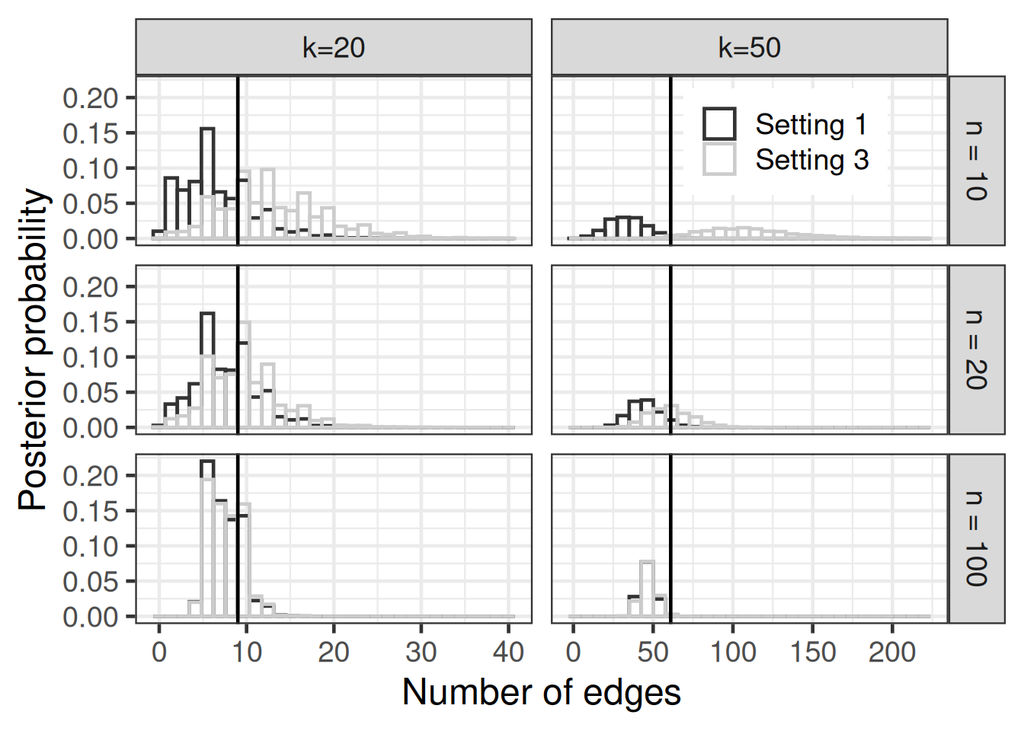

```r
vline_data <- data.frame(k=names(kseq), true_nbedges= sapply(Theta_truth, function(z) sum(z[upper.tri(z)] != 0)))

ggplot(sims_nbedges, aes(x=number_edges, col=Setting)) +
  geom_histogram(aes(y = after_stat(density)), fill=NA, position="identity") +
  geom_vline(data = vline_data, aes(xintercept = true_nbedges)) +
  facet_grid(rows= vars(n), cols= vars(k), scale="free_x", labeller=labeller(n = function(x) paste0("n = ", x))) +
  theme_bw(base_size = 18) +
  theme(legend.position = c(0.8, 0.88), legend.title = element_blank()) +
  scale_color_grey() +
  xlab("Number of edges") +
  ylab("Posterior probability")
```

```r
fname <- "sim_transferlearn_modelsize.pdf"
if (save2pdf) ggsave(fname)
```

We show the average posterior marginal inclusion probability $P(\Theta_{ij} \neq 0 \mid y)$ for prior settings 1 and 3, separately for each $(k,n)$ combination.

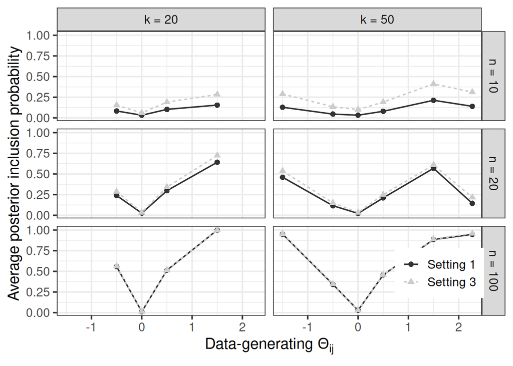

```r
filter(sim_summary, !(truth %in% diagvals)) |>
ggplot(aes(x=truth, y=pp, col=Setting, lty=Setting, pch=Setting)) +
  geom_line() +
  geom_point() +
  facet_grid(rows=vars(n), cols=vars(k),
             labeller = labeller(n = function(x) paste0("n = ", x), k = function(x) paste0("k = ", x))) +
  theme_bw(base_size = 15) +
  theme(legend.position = c(0.9, 0.15), legend.title=element_blank()) +
  scale_color_grey() +
  xlab(expression("Data-generating " * Theta[ij])) +
  ylab("Average posterior inclusion probability")
```

```r
fname <- "sim_transferlearn_pp.pdf"
if (save2pdf) ggsave(fname)
```

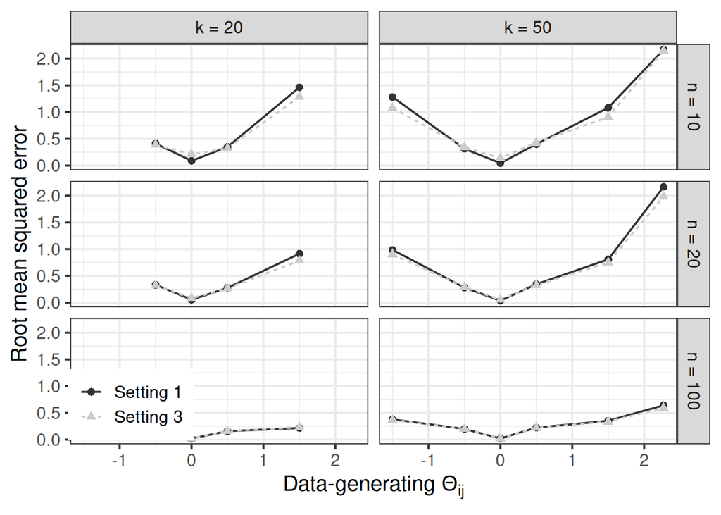

```r
filter(sim_summary, !(truth %in% diagvals)) |>
ggplot(aes(x=truth, y=root_mse, col=Setting, lty=Setting, pch=Setting)) +
  geom_line() +
  geom_point() +
  facet_grid(rows=vars(n), cols=vars(k),
             labeller = labeller(n = function(x) paste0("n = ", x), k = function(x) paste0("k = ", x))) +
  theme_bw(base_size = 15) +
  theme(legend.position = c(0.1, 0.1), legend.title=element_blank()) +
  scale_color_grey() +
  xlab(expression("Data-generating " * Theta[ij])) +
  ylab("Root mean squared error")
```

```r
fname <- "sim_transferlearn_rootmse_nodiag.pdf"
if (save2pdf) ggsave(fname)
```